# Affordable Housing

```r
library(tidyverse)
library(glue)
library(sf)
```

1. filtered_sales.csv:
   - Contains sales of single family homes from 1995 to October of 2022.
   - Non arms-length transactions and transactions for parcels which did not have a house on them at the time of sale. This was done by removing any transactions for $0, any transactions for which the adjacent appraisal values showed $0 for improvements, and any for which the transaction amount was less than half of the adjacent appraisals.
   - Optional: If you would like to work with the full dataset, all transactions are contained in full_sales.csv and the assessment values are in assessment.csv.

```r
filtered_sales <- read_csv('../data/filtered_sales.csv')
filtered_sales
```

| apn | amount | ownerdate |
| --- | --- | --- |
| 00200000300 | 95000 | 2010-12-22 |
| 00200000300 | 95000 | 2010-12-22 |
| 00200000700 | 115000 | 2004-11-24 |
| 00200001001 | 250000 | 2022-09-02 |
| 00200002401 | 95800 | 2001-10-12 |
| 00200002401 | 95800 | 2001-10-12 |
| 00200002401 | 129500 | 2007-01-31 |
| 00200002401 | 129500 | 2007-01-31 |
| 00200002401 | 106600 | 2011-12-28 |
| 00200002401 | 96500 | 2013-05-07 |

[output cut: 990 more lines]

```
2. LIHTC.csv
* Details of affordable housing developments funded by the LIHTC program.
* Refer to the included data dictionary for variable descriptions.
```

```r
lihtc <- read_csv('../data/LIHTC.csv') |>
  rename_all(tolower) |>
  mutate_at(vars(yr_pis, yr_alloc), ~na_if(., 8888)) |>
  mutate_at(vars(yr_pis, yr_alloc), ~na_if(., 9999)) |>
  mutate(yr_pis = ymd(paste(yr_pis, '01-01', sep = '-'))) |>
  mutate(yr_alloc = ymd(paste(yr_alloc, '01-01', sep='-'))) |>
  select(hud_id,
         project,
         proj_add,
         proj_zip,
         allocamt,
         latitude,
         longitude,
         yr_pis,
         yr_alloc)
```

[output not shown]

```r
lihtc
```

| hud_id | project | proj_add | proj_zip | allocamt | latitude | longitude | yr_pis | yr_alloc |
| --- | --- | --- | --- | --- | --- | --- | --- | --- |
| TNA00000008 | CUMBERLAND POINTE APTS | 2400 BUENA VISTA PIKE | 37218 | NA | 36.19992 | -86.82510 |  | 2013-01-01 |
| TNA00000011 | HICKORY LAKE APTS | 3940 APACHE TRAIL | 37013 | NA | 36.06726 | -86.69102 |  | 2013-01-01 |
| TNA00000023 | SEVEN HUNDRED FIVE WOODLAND | 705 WOODLAND ST | 37206 | NA | 36.17381 | -86.76006 |  | 2011-01-01 |
| TNA0000X003 | LEVY PLACE | 303 FOSTER ST. | 37207 | 0 | 36.17900 | -86.76743 |  | 2015-01-01 |
| TNA0000X005 | THE PADDOCK AT GRANDVIEW | 230 W. TRINITY LANE | 11111 | 0 | 36.20652 | -86.77901 |  |  |
| TNA19870020 | 117 W TRINITY LN | 117 W TRINITY LN | 37207 | NA | 36.20619 | -86.77045 | 1987-01-01 | 1987-01-01 |
| TNA19870090 | FIFTH AVE SFD | 1631 FIFTH AVE N | 37208 | 2070 | 36.18171 | -86.79242 | 1987-01-01 | 1987-01-01 |
| TNA19870800 | FIFTH STREET SFD | 1102 N FIFTH ST | 37207 | 495 | 36.19067 | -86.76261 | 1987-01-01 | 1987-01-01 |
| TNA19870805 | 209 A&B PRINCE AVE | 209A PRINCE AVE | 37207 | 4115 | 36.20654 | -86.76417 | 1987-01-01 | 1987-01-01 |
| TNA19870806 | 909 C&D THOMAS AVE | 909C THOMAS AVE | 37216 | 4386 | 36.20527 | -86.74011 | 1987-01-01 | 1987-01-01 |

[output cut: 167 more lines]

```
3. barnes.csv
* Contains information on rental properties that are completed and have more than 10 units which were funded by the Barnes Fund.
```

```r
barnes <- read_csv('../data/barnes.csv') |>
  rename(latitude = lat, longitude = lng) |>
  select(latitude,
          longitude,
          `Barnes Year`,
          `Affordability Term Start Date`)
barnes
```

| latitude | longitude | Barnes Year | Affordability Term Start Date |
| --- | --- | --- | --- |
| 36.18609 | -86.81979 | 2014 | 2018-10-31 |
| 36.15562 | -86.81162 | 2016 | 2020-03-01 |
| 36.18601 | -86.81909 | 2016 | 2019-11-22 |
| 36.17638 | -86.60310 | 2016 | 2017-07-13 |
| 36.12972 | -86.75164 | 2017 | 2020-10-02 |
| 36.24869 | -86.71189 | 2017 | 2019-12-06 |
| 36.15351 | -86.76586 | 2019 | 2022-04-01 |
| 36.19713 | -86.83564 | 2019 | 2022-06-27 |
| 36.14459 | -86.74640 | 2019 | 2021-04-19 |

4. property_details.csv
   - Contains detailed information on each property, including year built, square footage, number of rooms, and location (lat/lng)

```r
prop_details <- read_csv('../data/property_details.csv')
prop_details
```

| apn | tract | year_built | land_area | square_footage | exterior_wall | story_height | building_condition | foundation_type | number_of_rooms | number_of_beds | number_of_baths | number_of_half_bath | number_of_fixtures | centroid |
| --- | --- | --- | --- | --- | --- | --- | --- | --- | --- | --- | --- | --- | --- | --- |
| 00200001001 | 37010202 | 1960 | 0.45 Acres | 1787 | BRICK | ONE STY | Average | PT BSMT | 6 | 3 | 2 | 0 | 8 | (-86.76450068092568,36.39310564099614) |
| 00200001400 | 37010202 | 1948 | 1.20 Acres | 736 | CONC BLK | ONE STY | Average | CRAWL | 4 | 2 | 1 | 0 | 5 | (-86.76109594681536,36.39486577609649) |
| 00200002000 | 37010202 | 1940 | 2.80 Acres | 2016 | FRAME | ONE STY | Average | CRAWL | 6 | 3 | 1 | 0 | 5 | (-86.75784637618023,36.39366859599204) |
| 00200002700 | 37010202 | 1940 | 1.15 Acres | 2627 | FRAME | ONE STY | Average | CRAWL | 8 | 4 | 2 | 0 | 8 | (-86.76308736156855,36.39356184510311) |
| 00300001200 | 37010202 | 1946 | 2.50 Acres | 1442 | FRAME | ONE STY | Average | CRAWL | 6 | 3 | 1 | 0 | 5 | (-86.74439293927152,36.398026155320046) |
| 00400001600 | 37010103 | 1985 | 28.52 Acres | 2373 | BRICK/FRAME | ONE STY | Average | PT BSMT | 6 | 3 | 3 | 0 | 10 | (-86.89020140543457,36.37609624305085) |
| 00400003700 | 37010103 | 1947 | 1.90 Acres | 2118 | FRAME | ONE STY | Average | PT BSMT | 7 | 4 | 2 | 0 | 8 | (-86.89343968928088,36.37267691504497) |
| 00400004100 | 37010103 | 1930 | 27.80 Acres | 2016 | BRICK | 1.5 STORY | Fair | PT BSMT | 7 | 4 | 1 | 0 | 5 | (-86.8936373780398,36.371161352318026) |
| 00400005100 | 37010103 | 1964 | 2.15 Acres | 1625 | BRICK | ONE STY | Average | CRAWL | 6 | 3 | 1 | 1 | 7 | (-86.88809231344094,36.36891872279261) |
| 00400005108 | 37010103 | 1920 | 1.08 Acres | 1463 | BRICK | 1.5 STORY | Average | CRAWL | 6 | 3 | 1 | 0 | 5 | (-86.89013017542902,36.371487177252085) |

[output cut: 990 more lines]

[output not shown]

```r
detailed_sales <- right_join(prop_details, filtered_sales, by='apn') |>
  mutate(
    longitude = as.numeric(str_extract(centroid,
                                       "\\((.+),", group = 1)),
    latitude = as.numeric(str_extract(centroid,
                                      ",(.+)\\)", group = 1)
                           )) |>
    mutate(ownerdate = ymd(ownerdate)) |>
  select(-centroid)
detailed_sales
```

| apn | tract | year_built | land_area | square_footage | exterior_wall | story_height | building_condition | foundation_type | number_of_rooms | number_of_beds | number_of_baths | number_of_half_bath | number_of_fixtures | amount | ownerdate | longitude | latitude |
| --- | --- | --- | --- | --- | --- | --- | --- | --- | --- | --- | --- | --- | --- | --- | --- | --- | --- |
| 00200001001 | 37010202 | 1960 | 0.45 Acres | 1787 | BRICK | ONE STY | Average | PT BSMT | 6 | 3 | 2 | 0 | 8 | 250000 | 2022-09-02 | -86.76450 | 36.39311 |
| 00200002700 | 37010202 | 1940 | 1.15 Acres | 2627 | FRAME | ONE STY | Average | CRAWL | 8 | 4 | 2 | 0 | 8 | 165000 | 2020-05-08 | -86.76309 | 36.39356 |
| 00200002700 | 37010202 | 1940 | 1.15 Acres | 2627 | FRAME | ONE STY | Average | CRAWL | 8 | 4 | 2 | 0 | 8 | 277500 | 2021-08-31 | -86.76309 | 36.39356 |
| 00200002700 | 37010202 | 1940 | 1.15 Acres | 2627 | FRAME | ONE STY | Average | CRAWL | 8 | 4 | 2 | 0 | 8 | 270000 | 2021-08-31 | -86.76309 | 36.39356 |
| 00200002700 | 37010202 | 1940 | 1.15 Acres | 2627 | FRAME | ONE STY | Average | CRAWL | 8 | 4 | 2 | 0 | 8 | 440000 | 2022-08-12 | -86.76309 | 36.39356 |
| 00400003700 | 37010103 | 1947 | 1.90 Acres | 2118 | FRAME | ONE STY | Average | PT BSMT | 7 | 4 | 2 | 0 | 8 | 255000 | 2017-10-27 | -86.89344 | 36.37268 |
| 00400005100 | 37010103 | 1964 | 2.15 Acres | 1625 | BRICK | ONE STY | Average | CRAWL | 6 | 3 | 1 | 1 | 7 | 295000 | 2022-06-06 | -86.88809 | 36.36892 |
| 00400005108 | 37010103 | 1920 | 1.08 Acres | 1463 | BRICK | 1.5 STORY | Average | CRAWL | 6 | 3 | 1 | 0 | 5 | 56240 | 2000-10-24 | -86.89013 | 36.37149 |
| 00400005108 | 37010103 | 1920 | 1.08 Acres | 1463 | BRICK | 1.5 STORY | Average | CRAWL | 6 | 3 | 1 | 0 | 5 | 43000 | 2000-11-21 | -86.89013 | 36.37149 |
| 00400008200 | 37010103 | 1998 | 2.00 Acres | 2387 | BRICK | ONE STY | Average | FULL BSMT | 8 | 4 | 3 | 0 | 11 | 230000 | 2003-04-17 | -86.88708 | 36.37034 |

[output cut: 990 more lines]

```r
lihtc_huds <- lihtc |>
  pull(hud_id)
```

```
Look at the Park at Richards Road Apartments, which are contained in LIHTC.csv and have a HUD ID of TNA20130015. These were allocated in 2012 and placed in service in 2013.
```

```r
hud <- 'TNA20130015'
```

Find all homes that are less than 2000 feet from this development (our “treatment” group) and all homes that are between 2000 and 3000 feet from this development (our “control” group). For these homes, find all sales that took place between 5 and 1 year before this development was allocated and all sales for 1 to 5 years after it was placed in service. You can use these as the “pre” and “post” sales.

```r
detailed_sales_sf <- st_as_sf(
  detailed_sales,
  coords = c('longitude', 'latitude'),
  crs = st_crs(4326)
  )
detailed_sales_sf |>
  slice_head(n=1)
```

```
Simple feature collection with 1 feature and 16 fields
Geometry type: POINT
Dimension:     XY
Bounding box:  xmin: -86.7645 ymin: 36.39311 xmax: -86.7645 ymax: 36.39311
Geodetic CRS:  WGS 84
```

| apn | tract | year_built | land_area | square_footage | exterior_wall | story_height | building_condition | foundation_type | number_of_rooms | number_of_beds | number_of_baths | number_of_half_bath | number_of_fixtures | amount | ownerdate | geometry |
| --- | --- | --- | --- | --- | --- | --- | --- | --- | --- | --- | --- | --- | --- | --- | --- | --- |
| 00200001001 | 37010202 | 1960 | 0.45 Acres | 1787 | BRICK | ONE STY | Average | PT BSMT | 6 | 3 | 2 | 0 | 8 | 250000 | 2022-09-02 |  |

```r
lihtc_sf <- st_as_sf(
  lihtc,
  coords = c('longitude', 'latitude'),
  crs = st_crs(4326)
  )

lihtc_sf |>
  head(1)
```

```
Simple feature collection with 1 feature and 7 fields
Geometry type: POINT
Dimension:     XY
Bounding box:  xmin: -86.8251 ymin: 36.19992 xmax: -86.8251 ymax: 36.19992
Geodetic CRS:  WGS 84
```

| hud_id | project | proj_add | proj_zip | allocamt | yr_pis | yr_alloc | geometry |
| --- | --- | --- | --- | --- | --- | --- | --- |
| TNA00000008 | CUMBERLAND POINTE APTS | 2400 BUENA VISTA PIKE | 37218 | NA |  | 2013-01-01 |  |

```r
barnes_sf <- st_as_sf(
  barnes,
  coords = c('longitude', 'latitude'),
  crs = st_crs(4326)
  ) |>
  mutate(hud_id = as.character(row_number())) |>
  rename(yr_alloc = `Barnes Year`, yr_pis = `Affordability Term Start Date`) |>
  mutate(yr_alloc = ymd(paste(yr_alloc, '01-01', sep='-')))

barnes_sf |>
  head(1)
```

```
Simple feature collection with 1 feature and 3 fields
Geometry type: POINT
Dimension:     XY
Bounding box:  xmin: -86.81979 ymin: 36.18609 xmax: -86.81979 ymax: 36.18609
Geodetic CRS:  WGS 84
```

| yr_alloc | yr_pis | geometry | hud_id |
| --- | --- | --- | --- |
| 2014-01-01 | 2018-10-31 |  | 1 |

```r
lihtc_sf_example <- lihtc_sf |>
  filter(hud_id == hud)

lihtc_sf_example
```

```
Simple feature collection with 1 feature and 7 fields
Geometry type: POINT
Dimension:     XY
Bounding box:  xmin: -86.67468 ymin: 36.06866 xmax: -86.67468 ymax: 36.06866
Geodetic CRS:  WGS 84
```

|  | hud_id | project | proj_add | proj_zip | allocamt | yr_pis | yr_alloc | geometry |
| --- | --- | --- | --- | --- | --- | --- | --- | --- |
| 1 | TNA20130015 | PARK AT RICHARDS ROAD APTS | 850 RICHARDS RD | 37013 | 100000 | 2013-01-01 | 2012-01-01 |  |

```r
lihtc_barnes <- bind_rows(lihtc_sf, barnes_sf)

lihtc_barnes
```

```
Simple feature collection with 186 features and 7 fields
Geometry type: POINT
Dimension:     XY
Bounding box:  xmin: -86.91273 ymin: 36.03909 xmax: -86.58607 ymax: 36.3463
Geodetic CRS:  WGS 84
```

|  | hud_id | project | proj_add | proj_zip | allocamt | yr_pis | yr_alloc | geometry |
| --- | --- | --- | --- | --- | --- | --- | --- | --- |
| 1 | TNA00000008 | CUMBERLAND POINTE APTS | 2400 BUENA VISTA PIKE | 37218 | NA |  | 2013-01-01 |  |
| 2 | TNA00000011 | HICKORY LAKE APTS | 3940 APACHE TRAIL | 37013 | NA |  | 2013-01-01 |  |
| 3 | TNA00000023 | SEVEN HUNDRED FIVE WOODLAND | 705 WOODLAND ST | 37206 | NA |  | 2011-01-01 |  |
| 4 | TNA0000X003 | LEVY PLACE | 303 FOSTER ST. | 37207 | 0 |  | 2015-01-01 |  |
| 5 | TNA0000X005 | THE PADDOCK AT GRANDVIEW | 230 W. TRINITY LANE | 11111 | 0 |  |  |  |
| 6 | TNA19870020 | 117 W TRINITY LN | 117 W TRINITY LN | 37207 | NA | 1987-01-01 | 1987-01-01 |  |
| 7 | TNA19870090 | FIFTH AVE SFD | 1631 FIFTH AVE N | 37208 | 2070 | 1987-01-01 | 1987-01-01 |  |
| 8 | TNA19870800 | FIFTH STREET SFD | 1102 N FIFTH ST | 37207 | 495 | 1987-01-01 | 1987-01-01 |  |
| 9 | TNA19870805 | 209 A&B PRINCE AVE | 209A PRINCE AVE | 37207 | 4115 | 1987-01-01 | 1987-01-01 |  |
| 10 | TNA19870806 | 909 C&D THOMAS AVE | 909C THOMAS AVE | 37216 | 4386 | 1987-01-01 | 1987-01-01 |  |

[output cut: 176 more lines]

```r
affordable_func <-  function(id) {
  example <- lihtc_barnes |>
    filter(hud_id == id)
  detailed_sales_sf <- detailed_sales_sf |>
  mutate(
    distance_in_feet = as.numeric(
      st_distance(
        geometry, st_geometry(
          example
          )
        ) * 3.28084
      )
    )
  pre_start = as.Date(example$yr_alloc - years(5))
  pre_stop = as.Date(example$yr_alloc - years(0))

  post_start =  as.Date(years(2) + example$yr_pis)
  post_stop = as.Date(years(7) + example$yr_pis)

  treat_dist = 2000
  control_dist = 3000

  pre_treatment = detailed_sales_sf |>
  filter(distance_in_feet <= treat_dist) |>
   filter(between(ownerdate,
                  pre_start,
                  pre_stop
                 )
          )
  post_treatment = detailed_sales_sf |>
  filter(distance_in_feet <= treat_dist) |>
   filter(between(ownerdate,
                  post_start,
                  post_stop
                 )
          )
  pre_control = detailed_sales_sf |>
  filter(between(distance_in_feet,
                 treat_dist,
                 control_dist)) |>
  filter(between(ownerdate,
                 pre_start,
                 pre_stop
                 )
          )
  post_control = detailed_sales_sf |>
  filter(between(distance_in_feet,
                 treat_dist,
                 control_dist)) |>
  filter(between(ownerdate,
                 post_start,
                 post_stop
                 )
          )
  combined_data <- bind_rows(
  mutate(pre_control, group = "Control", time = "Pre"),
  mutate(post_control, group = "Control", time = "Post"),
  mutate(pre_treatment, group = "Treatment", time = "Pre"),
  mutate(post_treatment, group = "Treatment", time = "Post")
)
  combined_data <- combined_data |>
    mutate(time = factor(time, levels = c('Pre', 'Post')))

}
```

```r
lihtc_barnes_huds <- lihtc_barnes |>
  pull(hud_id)
```

```r
detailed_sales_sf <- detailed_sales_sf |>
  mutate(
    distance_in_feet = as.numeric(
      st_distance(
        geometry, st_geometry(
          lihtc_sf_example
          )
        ) * 3.28084
      )
    )
```

Checking tibble for accuracy

```r
detailed_sales_sf |>
  filter(distance_in_feet < 200)
```

```
Simple feature collection with 8 features and 17 fields
Geometry type: POINT
Dimension:     XY
Bounding box:  xmin: -86.67498 ymin: 36.06822 xmax: -86.67458 ymax: 36.06919
Geodetic CRS:  WGS 84
```

|  | apn | tract | year_built | land_area | square_footage | exterior_wall | story_height | building_condition | foundation_type | number_of_rooms | number_of_beds | number_of_baths | number_of_half_bath | number_of_fixtures | amount | ownerdate | geometry | distance_in_feet |
| --- | --- | --- | --- | --- | --- | --- | --- | --- | --- | --- | --- | --- | --- | --- | --- | --- | --- | --- |
| 1 | 14812006200 | 37015627 | 1963 | 0.33 Acres | 1050 | BRICK | ONE STY | Average | PT BSMT | 5 | 3 | 1 | 1 | 7 | 110000 | 2005-10-27 |  | 161.9468 |
| 2 | 14812004600 | 37015615 | 1964 | 0.40 Acres | 2000 | BRICK | BI-LEVEL | Average | SLAB | 7 | 3 | 1 | 0 | 5 | 90000 | 1999-03-01 |  | 130.3730 |
| 3 | 14812018000 | 37015615 | 1971 | 0.23 Acres | 1200 | BRICK | ONE STY | Average | FULL BSMT | 5 | 3 | 1 | 1 | 7 | 115000 | 2004-06-25 |  | 193.7062 |
| 4 | 14812017900 | 37015615 | 1971 | 0.23 Acres | 1760 | BRICK | ONE STY | Average | FULL BSMT | 5 | 3 | 1 | 1 | 7 | 100000 | 2003-02-20 |  | 118.7607 |
| 5 | 14812017900 | 37015615 | 1971 | 0.23 Acres | 1760 | BRICK | ONE STY | Average | FULL BSMT | 5 | 3 | 1 | 1 | 7 | 130900 | 2007-03-07 |  | 118.7607 |
| 6 | 14812017900 | 37015615 | 1971 | 0.23 Acres | 1760 | BRICK | ONE STY | Average | FULL BSMT | 5 | 3 | 1 | 1 | 7 | 82319 | 2012-07-26 |  | 118.7607 |
| 7 | 14812017900 | 37015615 | 1971 | 0.23 Acres | 1760 | BRICK | ONE STY | Average | FULL BSMT | 5 | 3 | 1 | 1 | 7 | 93000 | 2013-02-28 |  | 118.7607 |
| 8 | 14812017900 | 37015615 | 1971 | 0.23 Acres | 1760 | BRICK | ONE STY | Average | FULL BSMT | 5 | 3 | 1 | 1 | 7 | 210000 | 2018-11-19 |  | 118.7607 |

Creates objects for time and group for use in variable tibble creation

```r
pre_start = year(lihtc_sf_example$yr_alloc - years(5))
pre_stop = year(lihtc_sf_example$yr_alloc - years(1))

post_start =  year(years(1) + lihtc_sf_example$yr_pis)
post_stop = year(years(5) + lihtc_sf_example$yr_pis)

treat_dist = 2000
control_dist = 3000
```

```r
pre_treatment = detailed_sales_sf |>
  filter(distance_in_feet <= treat_dist) |>
   filter(between(year(ownerdate),
                  pre_start,
                  pre_stop
                 )
          )
```

```r
post_treatment = detailed_sales_sf |>
  filter(distance_in_feet <= treat_dist) |>
   filter(between(year(ownerdate),
                  post_start,
                  post_stop
                 )
          )
```

```r
pre_control = detailed_sales_sf |>
  filter(between(distance_in_feet,
                 treat_dist,
                 control_dist)) |>
  filter(between(year(ownerdate),
                 pre_start,
                 pre_stop
                 )
          )
```

```r
post_control = detailed_sales_sf |>
  filter(between(distance_in_feet,
                 treat_dist,
                 control_dist)) |>
  filter(between(year(ownerdate),
                 post_start,
                 post_stop
                 )
          )
```

Use a difference in differences approach to estimate whether this development had an impact on sales prices. Start with a basic model for the sales amount based on the pre/post and treatment/control variables only. Can we conclude that the sales price for nearby homes was affected by the development?

```r
combined_data <- bind_rows(
  mutate(pre_control, group = "Control", time = "Pre"),
  mutate(post_control, group = "Control", time = "Post"),
  mutate(pre_treatment, group = "Treatment", time = "Pre"),
  mutate(post_treatment, group = "Treatment", time = "Post")
)
combined_data <- combined_data |>
  mutate(time = factor(time, levels = c('Pre', 'Post')))
```

```r
combined_data |>
  group_by(group, time) |>
  summarize(amount = mean(amount), n())
```

```
Simple feature collection with 4 features and 4 fields
Geometry type: MULTIPOINT
Dimension:     XY
Bounding box:  xmin: -86.68364 ymin: 36.06147 xmax: -86.66472 ymax: 36.0767
Geodetic CRS:  WGS 84
```

| group | time | amount | n() | geometry |
| --- | --- | --- | --- | --- |
| Control | Pre | 130147.8 | 192 |  |
| Control | Post | 162526.3 | 157 |  |
| Treatment | Pre | 111239.6 | 188 |  |
| Treatment | Post | 136043.1 | 148 |  |

```r
model <-  glm(amount ~ group + time + (group:time),
              data = combined_data)

summary(model)
```

[output not shown]

After doing this basic model, you might try adding some predictors to your model, like the square footage or age of the home. You might also try using the log of the sales price as the target.

```r
age_model <-  glm(amount ~ year_built + group + time + (group:time), data = combined_data)

summary(age_model)
```

```
Call:
glm(formula = amount ~ year_built + group + time + (group:time),
    data = combined_data)

Coefficients:
                          Estimate Std. Error t value
(Intercept)             -2061589.5  1346838.6  -1.531
year_built                  1108.4      681.1   1.627
groupTreatment            -10314.7    23589.7  -0.437
timePost                   31124.8    24123.0   1.290
groupTreatment:timePost    -5446.9    34487.3  -0.158
                        Pr(>|t|)
(Intercept)                0.126
year_built                 0.104
groupTreatment             0.662
timePost                   0.197
groupTreatment:timePost    0.875

(Dispersion parameter for gaussian family taken to be 50210510240)

    Null deviance: 3.4505e+13  on 684  degrees of freedom
Residual deviance: 3.4143e+13  on 680  degrees of freedom
AIC: 18829

Number of Fisher Scoring iterations: 2
```

```r
sq_model <-  glm(amount ~ square_footage + group + time + (group:time), data = combined_data)

summary(sq_model)
```

```
Call:
glm(formula = amount ~ square_footage + group + time + (group:time),
    data = combined_data)

Coefficients:
                          Estimate Std. Error t value
(Intercept)             116290.492  34502.761   3.370
square_footage               9.763     21.462   0.455
groupTreatment          -20183.012  23202.186  -0.870
timePost                 32047.253  24164.893   1.326
groupTreatment:timePost  -7349.744  34527.827  -0.213
                        Pr(>|t|)
(Intercept)             0.000793 ***
square_footage          0.649333
groupTreatment          0.384675
timePost                0.185222
groupTreatment:timePost 0.831497
---
Signif. codes:
0 ‘***’ 0.001 ‘**’ 0.01 ‘*’ 0.05 ‘.’ 0.1 ‘ ’ 1

(Dispersion parameter for gaussian family taken to be 50390742587)

    Null deviance: 3.4505e+13  on 684  degrees of freedom
Residual deviance: 3.4266e+13  on 680  degrees of freedom
AIC: 18831

Number of Fisher Scoring iterations: 2
```

```r
log_model <-  lm(log(amount) ~ group + time + group:time + square_footage + year_built + building_condition, data = combined_data)

summary(log_model)
```

```
Call:
lm(formula = log(amount) ~ group + time + group:time + square_footage +
    year_built + building_condition, data = combined_data)

Residuals:
    Min      1Q  Median      3Q     Max
-1.6158 -0.2493 -0.0025  0.2066  3.4417

Coefficients:
                          Estimate Std. Error t value
(Intercept)              8.378e-01  3.021e+00   0.277
groupTreatment           7.573e-02  5.186e-02   1.460
timePost                 3.354e-01  5.279e-02   6.353
square_footage           2.208e-04  4.809e-05   4.591
year_built               5.175e-03  1.520e-03   3.404
building_conditionFair  -4.454e-01  2.031e-01  -2.193
groupTreatment:timePost -1.282e-02  7.542e-02  -0.170
                        Pr(>|t|)
(Intercept)             0.781639
groupTreatment          0.144719
timePost                3.86e-10 ***
square_footage          5.25e-06 ***
year_built              0.000703 ***
building_conditionFair  0.028610 *
groupTreatment:timePost 0.865056
---
Signif. codes:
0 ‘***’ 0.001 ‘**’ 0.01 ‘*’ 0.05 ‘.’ 0.1 ‘ ’ 1

Residual standard error: 0.4898 on 678 degrees of freedom
Multiple R-squared:  0.1478,    Adjusted R-squared:  0.1402
F-statistic: 19.59 on 6 and 678 DF,  p-value: < 2.2e-16
```

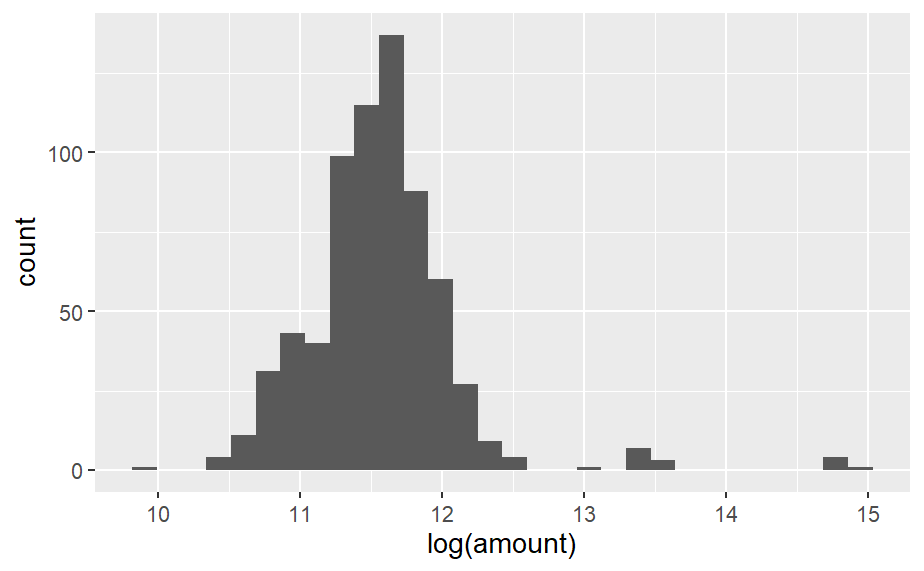

```r
combined_data |>
  ggplot(aes(x = log(amount))) +
  geom_histogram()
```

Finally, try instead of using a binary variable for before or after to use a tpost variable indicating the number of years before or after the development that the sale took place. Do your conclusions change?

```r
t_post_model <- glm(amount ~ time + I(ownerdate - 2013) + time:I(ownerdate - 2013), data = combined_data)

summary(t_post_model)
```

```
Call:
glm(formula = amount ~ time + I(ownerdate - 2013) + time:I(ownerdate -
    2013), data = combined_data)

Coefficients:
                               Estimate Std. Error
(Intercept)                   9.555e+05  2.591e+05
timePost                     -2.318e+06  4.424e+05
I(ownerdate - 2013)          -6.792e+01  2.106e+01
timePost:I(ownerdate - 2013)  1.686e+02  3.183e+01
                             t value Pr(>|t|)
(Intercept)                    3.688 0.000244 ***
timePost                      -5.240 2.14e-07 ***
I(ownerdate - 2013)           -3.225 0.001321 **
timePost:I(ownerdate - 2013)   5.298 1.58e-07 ***
---
Signif. codes:
0 ‘***’ 0.001 ‘**’ 0.01 ‘*’ 0.05 ‘.’ 0.1 ‘ ’ 1

(Dispersion parameter for gaussian family taken to be 48453355567)

    Null deviance: 3.4505e+13  on 684  degrees of freedom
Residual deviance: 3.2997e+13  on 681  degrees of freedom
AIC: 18804

Number of Fisher Scoring iterations: 2
```

Modify your code so that it works on other developments. Are your findings the same?

Next, rather than focusing on a single development at time, modify your model to consider all housing developments. Note that you’ll likely want to include the sales year as an explanatory variable in your model.

```r
li_ba_map <- map(lihtc_barnes_huds,
                 affordable_func,
                 .progress = TRUE)

li_ba_bind <- bind_rows(li_ba_map)
```

```r
glm(amount ~ time + group + C(year(ownerdate)) + (time:group), data = li_ba_bind) |>
  summary()
```

[output not shown]

**Bonus:** [Assessing the Impact of Affordable Housing on Nearby Property Values in Alexandria, Virginia](https://www.urban.org/research/publication/assessing-impact-affordable-housing-nearby-property-values-alexandria-virginia) also looks at the impact of affordable housing developments on nearby property values, but uses a different model which focuses only on homes that were sold both before and after the development was placed in service. Use a similar setup to analyze the data from Davidson County.